# KSPZV1 DGE Δ (postvax/baseline) edgeR for 1.8 x 10^6 PfSPZ group

Tuan M. Tran

09/28/2021

### Objective

Perform differential gene expression using edgeR to assess differences betwee protected (P) and not protected (NP) infants in the KSPZV1 malaria vaccine trial. This analysis specifically evaluates differences in post-vax with adjustment for baseline.

```r
library(knitr)
library(tidyverse)
library(edgeR)
library(googledrive)
library(tidyverse)
library(fgsea)
library(data.table)
library(EDASeq)
```

### Load ExpressionSet

```r
#from google drive
temp <- tempfile(fileext = ".rds")
dl <- drive_download(
  as_id("17P7RwDaPCwDXcrD82N4fYd3vGOcueFEH"), path = temp, overwrite = TRUE)
x <- readRDS(file = dl$local_path)
x$treat <- factor(x$treat, levels = c("Placebo", "4.5 x 10^5 PfSPZ", "9.0 x 10^5 PfSPZ", "1.8 x 10^6 PfSPZ"))
```

### Set options

```r
myGroups <- unique(x$treat)
```

```r
xgroup <- setNames(as.list(c(1:4)), c("Placebo", "4.5 x 10^5 PfSPZ", "9.0 x 10^5 PfSPZ", "1.8 x 10^6 PfSPZ"))
for(i in names(xgroup)){
  xgroup[[i]] <- x[, which(x$treat == i)]
  xgroup[[i]] <- xgroup[[i]][,xgroup[[i]]$Timepoint == 0 | xgroup[[i]]$Timepoint == 25]
  xgroup[[i]]$treat <- droplevels(xgroup[[i]]$treat)
  print(i)
  print(table(Outcome = xgroup[[i]]$Outcome, Timepoint = xgroup[[i]]$Timepoint))
  print(table(Outcome = xgroup[[i]]$Outcome, Dosegroup = xgroup[[i]]$treat))
  print(dim(xgroup[[i]]))
}
```

```
## [1] "Placebo"
##        Timepoint
## Outcome  0 25
##       0 26 26
##       1 39 37
##        Dosegroup
## Outcome Placebo
##       0      52
##       1      76
## Features  Samples
##    35716      128
## [1] "4.5 x 10^5 PfSPZ"
##        Timepoint
## Outcome  0 25
##       0 29 29
##       1 29 32
##        Dosegroup
## Outcome 4.5 x 10^5 PfSPZ
##       0               58
##       1               61
## Features  Samples
##    35716      119
## [1] "9.0 x 10^5 PfSPZ"
##        Timepoint
## Outcome  0 25
##       0 29 28
##       1 29 26
##        Dosegroup
## Outcome 9.0 x 10^5 PfSPZ
##       0               57
##       1               55
## Features  Samples
##    35716      112
## [1] "1.8 x 10^6 PfSPZ"
##        Timepoint
## Outcome  0 25
##       0 38 38
##       1 25 27
##        Dosegroup
## Outcome 1.8 x 10^6 PfSPZ
##       0               76
##       1               52
## Features  Samples
##    35716      128
```

### Reduce to high dose only

This reduces the time and enables the code to be knitted without throwing errors related to url connections. Can leave out if all treatment groups are analyzed when script is ran locally.

```r
myList <- c("1.8 x 10^6 PfSPZ")
for (name in myList) {
  xgroup <- xgroup[name]
}
```

### Build DGEList Object

```r
#Define group by dose, timepoint and outcome
ygroup <- xgroup
for(i in names(ygroup)){
  ygroup[[i]]  <- DGEList(counts=counts(xgroup[[i]]), genes=fData(xgroup[[i]]), group= factor(paste(xgroup[[i]]$treat, xgroup[[i]]$Timepoint, xgroup[[i]]$Outcome, sep = "_")), remove.zeros=T)
  ygroup[[i]]$samples$PATID <- gsub("_.*", "", rownames(ygroup[[i]]$samples))
}
```

### Filter out low expression features

```r
for(i in names(ygroup)){
  keep <- filterByExpr(ygroup[[i]])
  ygroup[[i]] <- ygroup[[i]][keep, , keep.lib.sizes=FALSE]
  ygroup[[i]]$samples$lib.size <- colSums(ygroup[[i]]$counts)
  ygroup[[i]] <- calcNormFactors(ygroup[[i]])   #Normalization
}
```

### Remove unpaired samples and then arrange by patient and timepoint

This is necessary for paired analyses.

```r
for(i in names(ygroup)){
  ygroup[[i]] <- ygroup[[i]][,!is.na(ygroup[[i]]$samples$group)]
  ygroup[[i]] <- ygroup[[i]][,duplicated(ygroup[[i]]$samples$PATID) | duplicated(ygroup[[i]]$samples$PATID, fromLast = TRUE)]
  ygroup[[i]] <- ygroup[[i]][,order(ygroup[[i]]$samples$PATID, ygroup[[i]]$samples$group)]
  print(i)
  print(ifelse(all(gsub('_.*', '', colnames(ygroup[[i]][,grepl("_0", colnames(ygroup[[i]]))])) ==
               gsub('_.*', '', colnames(ygroup[[i]][,grepl("_25", colnames(ygroup[[i]]))]))) &
           all(ygroup[[i]]$samples$Timepoint == rep(c(0,25),length(ygroup[[i]]$samples$Timepoint)/2)),
         "Samples are paired. All is good.","Stop and check order of samples."))
}
```

```
## [1] "1.8 x 10^6 PfSPZ"
## [1] "Samples are paired. All is good."
```

### Remake ExpressionSet after sample and feature (gene) filtering steps.

```r
for(i in names(ygroup)){
  myintersection <- intersect(rownames(pData(xgroup[[i]])), colnames(ygroup[[i]]$counts))
  xgroup[[i]] <- newSeqExpressionSet(counts = ygroup[[i]]$counts[,myintersection],
                           featureData = AnnotatedDataFrame(fData(xgroup[[i]])[which(rownames(fData(xgroup[[i]])) %in% rownames(ygroup[[i]]$counts)),]),
                           phenoData = AnnotatedDataFrame(pData(xgroup[[i]])[myintersection,]))
}
```

### Design Matrix - Compare Protected vs Not Protected

Analysis between Protected and Not Protected within a Dose Group

```r
DeltaDelta <- DeltaNotProtected <- DeltaProtected <- fit <- design <- xgroup
for(i in names(xgroup)){
  Subject <- factor(xgroup[[i]]$PATID)
  Outcome <- factor(xgroup[[i]]$Outcome, levels = c(1,0), labels = c("NotProtected","Protected"))
  Timepoint <- factor(xgroup[[i]]$Timepoint, levels = c(0,25), labels = c("baseline","postvax"))
  Age <- xgroup[[i]]$age.vax1
  Sex <- as.factor(xgroup[[i]]$SEX)
  Batch <- factor(xgroup[[i]]$SEQBATCH, levels = c("Aug2019","Nov2019"))
  MALdVax <- factor(xgroup[[i]]$mal.dvax, levels = c(0,1), labels = c("noMALdVAX","yesMALdVAX"))
  CSPAb_baseline <- as.numeric(xgroup[[i]]$pfcsp_pre)
  #Impute 2 missing values with median of all samples
  CSPAb_baseline[is.na(CSPAb_baseline)] <- median(CSPAb_baseline, na.rm = TRUE)
  #Define protective outcome-specific PfSPZ Vaccination effects and append them to the design matrix
  Protected.Postvax <- Outcome == "Protected" & Timepoint=="postvax"
  NotProtected.Postvax <- Outcome =="NotProtected" & Timepoint=="postvax"
  design[[i]] <- model.matrix(~Subject)
  #make design matrix according to edgeR 3.5 (p42)
  #https://www.bioconductor.org/packages/release/bioc/vignettes/edgeR/inst/doc/edgeRUsersGuide.pdf
  design[[i]] <- cbind(design[[i]], Protected.Postvax, NotProtected.Postvax)
  rownames(design[[i]]) <- xgroup[[i]]$PATID
  print(i)
  print(colnames(design[[i]])) #check colnames
  ygroup[[i]]     <- estimateDisp(ygroup[[i]],design[[i]], robust = TRUE)
  fit   <- glmQLFit(ygroup[[i]], design[[i]], robust = TRUE)
  qlf <- glmQLFTest(fit, coef="Protected.Postvax")
  DeltaProtected[[i]] <- topTags(qlf, n = nrow(xgroup[[i]]))$table
  qlf <- glmQLFTest(fit, coef="NotProtected.Postvax")
  DeltaNotProtected[[i]] <- topTags(qlf, n = nrow(xgroup[[i]]))$table
  qlf <- glmQLFTest(fit, contrast = c(rep(0,(ncol(design[[i]])-2)),1,-1))
  DeltaDelta[[i]] <- topTags(qlf, n = nrow(xgroup[[i]]))$table
}
```

```
## [1] "1.8 x 10^6 PfSPZ"
##  [1] "(Intercept)"          "SubjectK1S0316"       "SubjectK1S0318"
##  [4] "SubjectK1S0324"       "SubjectK1S0332"       "SubjectK1S0402"
##  [7] "SubjectK1S0411"       "SubjectK1S0419"       "SubjectK1S0421"
## [10] "SubjectK1S0422"       "SubjectK1S0431"       "SubjectK1S0436"
## [13] "SubjectK1S0448"       "SubjectK1S0524"       "SubjectK1S0532"
## [16] "SubjectK1S0544"       "SubjectK1S0608"       "SubjectK1S0621"
## [19] "SubjectK1S0623"       "SubjectK1S0635"       "SubjectK1S0636"
## [22] "SubjectK1S0638"       "SubjectK1S0641"       "SubjectK1S0644"
## [25] "SubjectK1S0719"       "SubjectK1S0724"       "SubjectK1S0733"
## [28] "SubjectK1S0735"       "SubjectK1S0736"       "SubjectK1S0743"
## [31] "SubjectK1S0808"       "SubjectK1S0815"       "SubjectK1W0351"
## [34] "SubjectK1W0367"       "SubjectK1W0386"       "SubjectK1W0389"
## [37] "SubjectK1W0399"       "SubjectK1W0460"       "SubjectK1W0462"
## [40] "SubjectK1W0463"       "SubjectK1W0477"       "SubjectK1W0484"
## [43] "SubjectK1W0490"       "SubjectK1W0493"       "SubjectK1W0494"
## [46] "SubjectK1W0496"       "SubjectK1W0581"       "SubjectK1W0590"
## [49] "SubjectK1W0592"       "SubjectK1W0650"       "SubjectK1W0660"
## [52] "SubjectK1W0662"       "SubjectK1W0668"       "SubjectK1W0671"
## [55] "SubjectK1W0752"       "SubjectK1W0773"       "SubjectK1W0781"
## [58] "SubjectK1W0788"       "SubjectK1W0859"       "SubjectK1W0860"
## [61] "SubjectK1W0875"       "Protected.Postvax"    "NotProtected.Postvax"
```

### Examine top 15 DEGs in 1.8x10^6 PfSPZ dose group

Δ Protected

|  | Description | EnsemblID | logFC | logCPM | F | PValue | FDR |
| --- | --- | --- | --- | --- | --- | --- | --- |
| ENSG00000137815 | RTF1 homolog, Paf1/RNA polymerase II complex component [Source:HGNC Symbol;Acc:HGNC:28996] | ENSG00000137815 | -0.2803414 | 5.679994 | 25.02532 | 0.0000047 | 0.0619147 |
| ENSG00000108389 | myotubularin related protein 4 [Source:HGNC Symbol;Acc:HGNC:7452] | ENSG00000108389 | -0.2375128 | 5.933196 | 24.25223 | 0.0000063 | 0.0619147 |
| ENSG00000270641 | TSIX transcript, XIST antisense RNA [Source:HGNC Symbol;Acc:HGNC:12377] | ENSG00000270641 | 9.2868728 | 9.285841 | 22.38686 | 0.0000176 | 0.1152504 |
| ENSG00000266086 | novel transcript | ENSG00000266086 | -0.3077507 | 4.202325 | 19.74225 | 0.0000361 | 0.1766256 |
| ENSG00000134684 | tyrosyl-tRNA synthetase 1 [Source:HGNC Symbol;Acc:HGNC:12840] | ENSG00000134684 | -0.2556819 | 6.154730 | 18.88531 | 0.0000509 | 0.1766256 |
| ENSG00000088930 | 5’-3’ exoribonuclease 2 [Source:HGNC Symbol;Acc:HGNC:12836] | ENSG00000088930 | -0.2386948 | 6.684393 | 18.74367 | 0.0000539 | 0.1766256 |
| ENSG00000150991 | ubiquitin C [Source:HGNC Symbol;Acc:HGNC:12468] | ENSG00000150991 | -0.3626272 | 7.470737 | 17.53003 | 0.0000885 | 0.2035280 |
| ENSG00000163798 | solute carrier family 4 member 1 adaptor protein [Source:HGNC Symbol;Acc:HGNC:13813] | ENSG00000163798 | -0.2590640 | 4.845450 | 17.46277 | 0.0000910 | 0.2035280 |
| ENSG00000009724 | mannan binding lectin serine peptidase 2 [Source:HGNC Symbol;Acc:HGNC:6902] | ENSG00000009724 | 0.3235910 | 3.899434 | 17.33580 | 0.0000959 | 0.2035280 |
| ENSG00000115053 | nucleolin [Source:HGNC Symbol;Acc:HGNC:7667] | ENSG00000115053 | -0.2932576 | 7.346159 | 17.07467 | 0.0001068 | 0.2035280 |
| ENSG00000147010 | SH3 domain containing kinase binding protein 1 [Source:HGNC Symbol;Acc:HGNC:13867] | ENSG00000147010 | -0.2594048 | 7.583826 | 16.92019 | 0.0001139 | 0.2035280 |
| ENSG00000214753 | heterogeneous nuclear ribonucleoprotein U like 2 [Source:HGNC Symbol;Acc:HGNC:25451] | ENSG00000214753 | -0.3377733 | 6.771758 | 16.14648 | 0.0001574 | 0.2578423 |
| ENSG00000160208 | ribosomal RNA processing 1B [Source:HGNC Symbol;Acc:HGNC:23818] | ENSG00000160208 | -0.2596929 | 5.985014 | 15.64482 | 0.0001946 | 0.2827653 |
| ENSG00000198431 | thioredoxin reductase 1 [Source:HGNC Symbol;Acc:HGNC:12437] | ENSG00000198431 | -0.2422311 | 5.993298 | 15.43101 | 0.0002131 | 0.2827653 |
| ENSG00000148826 | NK6 homeobox 2 [Source:HGNC Symbol;Acc:HGNC:19321] | ENSG00000148826 | 1.0946185 | 1.170875 | 15.40105 | 0.0002158 | 0.2827653 |

Δ Not Protected

|  | Description | EnsemblID | logFC | logCPM | F | PValue | FDR |
| --- | --- | --- | --- | --- | --- | --- | --- |
| ENSG00000257167 | TMPO antisense RNA 1 [Source:HGNC Symbol;Acc:HGNC:44158] | ENSG00000257167 | 0.3996496 | 5.1560262 | 15.557678 | 0.0002019 | 1 |
| ENSG00000171954 | cytochrome P450 family 4 subfamily F member 22 [Source:HGNC Symbol;Acc:HGNC:26820] | ENSG00000171954 | 1.8843383 | 0.7201115 | 15.165233 | 0.0002386 | 1 |
| ENSG00000232807 | novel transcript, antisense to FBXO18 | ENSG00000232807 | -0.3454261 | 3.6170997 | 14.369713 | 0.0003360 | 1 |
| ENSG00000258964 | novel transcript | ENSG00000258964 | -0.3786361 | 4.0420747 | 12.669146 | 0.0007088 | 1 |
| ENSG00000119711 | aldehyde dehydrogenase 6 family member A1 [Source:HGNC Symbol;Acc:HGNC:7179] | ENSG00000119711 | -0.4079183 | 5.0912565 | 11.564664 | 0.0011649 | 1 |
| ENSG00000140612 | SEC11 homolog A, signal peptidase complex subunit [Source:HGNC Symbol;Acc:HGNC:17718] | ENSG00000140612 | 0.2885858 | 5.3035857 | 11.526734 | 0.0011852 | 1 |
| ENSG00000262874 | chromosome 19 open reading frame 84 [Source:HGNC Symbol;Acc:HGNC:27112] | ENSG00000262874 | 1.4947230 | 0.6499098 | 11.340810 | 0.0012900 | 1 |
| ENSG00000213889 | protein phosphatase, Mg2+/Mn2+ dependent 1N (putative) [Source:HGNC Symbol;Acc:HGNC:26845] | ENSG00000213889 | 0.7943274 | 2.3702036 | 10.350036 | 0.0020362 | 1 |
| ENSG00000157837 | signal peptide peptidase like 3 [Source:HGNC Symbol;Acc:HGNC:30424] | ENSG00000157837 | -0.2108694 | 5.7443953 | 10.074085 | 0.0023160 | 1 |
| ENSG00000137075 | ring finger protein 38 [Source:HGNC Symbol;Acc:HGNC:18052] | ENSG00000137075 | -0.1877806 | 7.3367633 | 10.035426 | 0.0023582 | 1 |
| ENSG00000183474 | GTF2H2 family member C [Source:HGNC Symbol;Acc:HGNC:31394] | ENSG00000183474 | -3.5435798 | -0.1146607 | 10.144184 | 0.0023905 | 1 |
| ENSG00000211784 | T cell receptor alpha variable 10 [Source:HGNC Symbol;Acc:HGNC:12103] | ENSG00000211784 | -0.9467805 | 0.5314472 | 9.626960 | 0.0028575 | 1 |
| ENSG00000136950 | actin related protein 2/3 complex subunit 5 like [Source:HGNC Symbol;Acc:HGNC:23366] | ENSG00000136950 | 0.2806224 | 4.2467805 | 9.467784 | 0.0030809 | 1 |
| ENSG00000279887 | TEC | ENSG00000279887 | 2.0070711 | -0.3748544 | 9.460798 | 0.0031455 | 1 |
| ENSG00000104472 | chromatin accessibility complex subunit 1 [Source:HGNC Symbol;Acc:HGNC:13544] | ENSG00000104472 | -0.2303392 | 5.6254765 | 9.380112 | 0.0032117 | 1 |

Δ Protected vs. Δ Not Protected

|  | Description | EnsemblID | logFC | logCPM | F | PValue | FDR |
| --- | --- | --- | --- | --- | --- | --- | --- |
| ENSG00000271793 | novel protein, SYNCRIP-SNX14 readthrough | ENSG00000271793 | -0.4527771 | 5.0102197 | 13.744014 | 0.0004411 | 0.9999871 |
| ENSG00000264920 | SP2 divergent transcript [Source:HGNC Symbol;Acc:HGNC:55330] | ENSG00000264920 | 0.6785965 | 3.1260417 | 13.018650 | 0.0006069 | 0.9999871 |
| ENSG00000259544 | novel transcript, antisense to AKAP13 | ENSG00000259544 | -0.5316316 | 3.0078747 | 12.511810 | 0.0007603 | 0.9999871 |
| ENSG00000158604 | transmembrane p24 trafficking protein 4 [Source:HGNC Symbol;Acc:HGNC:22301] | ENSG00000158604 | 0.2314536 | 6.3425972 | 12.412846 | 0.0007947 | 0.9999871 |
| ENSG00000227751 | RCC2 antisense RNA 1 [Source:HGNC Symbol;Acc:HGNC:41262] | ENSG00000227751 | -0.7620318 | 1.6379689 | 12.253620 | 0.0008535 | 0.9999871 |
| ENSG00000245261 | novel transcript | ENSG00000245261 | 0.9459210 | 1.1566712 | 12.138520 | 0.0008988 | 0.9999871 |
| ENSG00000100726 | telomere maintenance 2 [Source:HGNC Symbol;Acc:HGNC:29099] | ENSG00000100726 | -0.8293710 | 3.1273975 | 11.862474 | 0.0010179 | 0.9999871 |
| ENSG00000279069 | novel transcript | ENSG00000279069 | -0.6437619 | 3.9077109 | 11.678593 | 0.0011062 | 0.9999871 |
| ENSG00000110651 | CD81 molecule [Source:HGNC Symbol;Acc:HGNC:1701] | ENSG00000110651 | -0.3638583 | 6.9081352 | 11.079169 | 0.0014540 | 0.9999871 |
| ENSG00000277595 | novel transcript, sense intronic to ANKRD13A | ENSG00000277595 | 0.7893252 | 1.6152034 | 10.331905 | 0.0020535 | 0.9999871 |
| ENSG00000261332 | novel transcript, antisense to ITGAL | ENSG00000261332 | -0.5043539 | 3.9795999 | 10.140782 | 0.0022449 | 0.9999871 |
| ENSG00000266086 | novel transcript | ENSG00000266086 | -0.3513690 | 4.2023254 | 10.137878 | 0.0022479 | 0.9999871 |
| ENSG00000102409 | brain expressed X-linked 4 [Source:HGNC Symbol;Acc:HGNC:25475] | ENSG00000102409 | 0.5708887 | 4.2468715 | 9.886352 | 0.0025290 | 0.9999871 |
| ENSG00000254662 | novel transcript | ENSG00000254662 | -0.9034323 | 0.6432803 | 9.668976 | 0.0028014 | 0.9999871 |
| ENSG00000126091 | ST3 beta-galactoside alpha-2,3-sialyltransferase 3 [Source:HGNC Symbol;Acc:HGNC:10866] | ENSG00000126091 | 0.4575722 | 2.8736934 | 9.367989 | 0.0032303 | 0.9999871 |

```r
AllDegs1 <- bind_rows(DeltaDelta, .id = "Treatment") %>%
  mutate(Comparison = "DeltaDelta")
AllDegs2 <- bind_rows(DeltaProtected, .id = "Treatment") %>%
  mutate(Comparison = "DeltaProtected")
AllDegs3 <- bind_rows(DeltaNotProtected, .id = "Treatment") %>%
  mutate(Comparison = "DeltaNotProtected")
AllDegs <- bind_rows(AllDegs1, AllDegs2, AllDegs3) %>%
  dplyr::select(Treatment, Comparison, EnsemblID, GeneSymbol, descripton_new, logFC, logCPM, "F", PValue, FDR) %>%
  dplyr::rename(Description = "descripton_new")

gois <- AllDegs %>%
  filter(Treatment == "1.8 x 10^6 PfSPZ") %>%
  droplevels() %>%
  dplyr::select(Treatment, Comparison, EnsemblID, GeneSymbol, Description, logFC, PValue, FDR) %>%
  pivot_wider(., names_from = Comparison, names_glue = "{Comparison}_{.value}", values_from = c(logFC, PValue, FDR)) %>%
  filter(DeltaDelta_PValue < 0.005 & (DeltaDelta_logFC > 0 & DeltaProtected_PValue < 0.05)) %>%
  arrange(DeltaDelta_PValue)

gois_ms <- gois %>%
  dplyr::select(GeneSymbol, DeltaDelta_logFC, DeltaDelta_PValue, DeltaProtected_logFC, DeltaProtected_PValue, DeltaNotProtected_logFC, DeltaNotProtected_PValue)
```

### Figure 4H in pre-print

| GeneSymbol | DeltaDelta_logFC | DeltaDelta_PValue | DeltaProtected_logFC | DeltaProtected_PValue | DeltaNotProtected_logFC | DeltaNotProtected_PValue |
| --- | --- | --- | --- | --- | --- | --- |
| SP2-DT | 0.6785965 | 0.0006069 | 0.3973724 | 0.0013223 | -0.2812242 | 0.0588251 |
| TMED4 | 0.2314536 | 0.0007947 | 0.1175334 | 0.0058746 | -0.1139202 | 0.0294511 |
| RP3-330M21.5 | 0.9459210 | 0.0008988 | 0.5090376 | 0.0037924 | -0.4368834 | 0.0434249 |
| RP11-946P6.6 | 0.7893252 | 0.0020535 | 0.4331951 | 0.0068779 | -0.3561300 | 0.0659737 |
| ST3GAL3 | 0.4575722 | 0.0032303 | 0.2635446 | 0.0067375 | -0.1940276 | 0.0997275 |
| GPATCH1 | 0.2467066 | 0.0033872 | 0.1034154 | 0.0460707 | -0.1432912 | 0.0265711 |

### Apply GSEA

Rank genes by -log10(PValue)*sign(logFC). Run fgsea from fgsea package using NamedGeneRankList2GseaTable helper function.

```r
set.seed(23)
#restructure dataframes
degtabs <- ygroup
for(i in names(ygroup)){
    degtabs[[i]] <- setNames(as.list(c(1:3)), c("DeltaDelta", "DeltaP", "DeltaNP"))
    degtabs[[i]]$DeltaDelta <- DeltaDelta[[i]]
    degtabs[[i]]$DeltaP <- DeltaProtected[[i]]
    degtabs[[i]]$DeltaNP <- DeltaNotProtected[[i]]
}
ranks <- degtabs
for(i in names(degtabs)){
  for(j in names(degtabs[[i]])){
    ranks[[i]][[j]] <-  degtabs[[i]][[j]] %>%
      mutate(rankmetric = -log10(.$PValue)*sign(.$logFC)) %>%
      dplyr::select(GeneSymbol,rankmetric) %>%
      na.omit() %>%
      distinct() %>%
      group_by(GeneSymbol) %>%
      summarize(rankmetric = mean(rankmetric)) %>%
      arrange(desc(rankmetric))
  }
}
#Run fgsea from fgsea package using NamedGeneRankList2GseaTable helper function
devtools::source_url("https://github.com/TranLab/ModuleLists/blob/main/NamedGeneRankList2GseaTable.R?raw=TRUE")
GSEAtab <- ranks
for(i in names(ranks)){
  for(j in names(ranks[[i]])){
    print(paste0("starting ", j, " in ", i))
    GSEAtab[[i]][[j]] <- NamedGeneRankList2GseaTable(rankedgenes = deframe(ranks[[i]][[j]]),
                                                     geneset = "all",
                                                     output_directory = tempdir(),
                                                     filename_prefix = "GSEA",
                                                     sampleSize = 101,
                                                     minSize = 20,
                                                     maxSize = Inf,
                                                     scoreType = "std") %>%
      as_tibble() %>%
      arrange(desc(NES)) %>%
      dplyr::select(module_type, pathway, ES, NES, size, leadingEdge, pval, padj) %>%
      mutate(leadingEdge = gsub("^c\\(|\\)$", "", leadingEdge)) %>%
      mutate(leadingEdge = gsub('"', "", leadingEdge)) %>%
      arrange(padj)
    #close(url) #this line prevents using up all url connections
  }
}
```

```
## [1] "starting DeltaDelta in 1.8 x 10^6 PfSPZ"
## [1] "Running fgsea for MonacoModules signatures"
## [1] "Running fgsea for highBTMs signatures"
## [1] "Running fgsea for lowBTMs signatures"
## [1] "Running fgsea for BloodGen3Module signatures"
## [1] "Running fgsea for MSigDB_Hallmark_v7.4 signatures"
## [1] "Running fgsea for MSigDB_C2_biocarta_v7.4 signatures"
## [1] "Running fgsea for MSigDB_C2_kegg_v7.4 signatures"
## [1] "Running fgsea for MSigDB_C8_all_v7.4 signatures"
## [1] "Running fgsea for MSigDB_C7_all_v7.4 signatures"
## [1] "Running fgsea for MSigDB_C5_GO_bp_v7.4 signatures"
## [1] "Running fgsea for MSigDB_C5_GO_mf_v7.4 signatures"
## [1] "starting DeltaP in 1.8 x 10^6 PfSPZ"
## [1] "Running fgsea for MonacoModules signatures"
## [1] "Running fgsea for highBTMs signatures"
```

[output cut: 21 more lines]

### Visualize GSEA data as bubble plot

Filter based on padj < 0.20.

```r
plotDat <- GSEAtab$`1.8 x 10^6 PfSPZ` %>%
  bind_rows(., .id = "comparison") %>%
  mutate(comparison = factor(comparison, levels = c("DeltaP", "DeltaNP", "DeltaDelta"), labels = c("DeltaP", "DeltaNP", "DeltaDelta"))) %>%
  filter(padj < 0.20) %>%
  filter(module_type %in% c("highBTMs", "lowBTMs", "MonacoModules", "BloodGen3Module", "MSigDB_Hallmark_v7.4"))  %>%
  filter(!grepl("TBA", pathway)) %>%
  dplyr::select(comparison, module_type, pathway, leadingEdge, size, NES, padj) %>%
  mutate(neglogpadj = -log10(padj)) %>%
  mutate(pathway = gsub("gd", "γδ", pathway)) %>%
  mutate(pathway = gsub("Vd2", "Vδ2", pathway)) %>%
  mutate(pathway = gsub("Vg", "Vγ", pathway)) %>%
  mutate(pathway = gsub("HALLMARK_", "", pathway)) %>%
  mutate(pathway = gsub("_", " ", pathway)) %>%
  mutate(pathway = sub(".*?\\_", "", pathway)) %>%
  group_by(module_type) %>%
  mutate(pathway = fct_reorder(pathway, NES, .desc = TRUE)) %>%
  ungroup() %>%
  filter(!grepl("TBD", pathway)) %>%
  mutate(module_type = factor(module_type, levels = c("highBTMs", "MonacoModules", "lowBTMs", "MSigDB_Hallmark_v7.4", "BloodGen3Module"))) %>%
  arrange(desc(neglogpadj)) %>%
  droplevels()

foodat <- plotDat %>%
  filter(comparison == "DeltaNP")
#plotting options
basetextsize <- 8
myfont <- "sans"
bubble_max_size <- 6

MyPlot <- plotDat %>%
  filter(module_type %in% c("highBTMs", "MonacoModules"))  %>%
  ggplot(., aes(x = comparison, y = pathway)) +
  geom_point(aes(size=neglogpadj, fill = NES), alpha = 0.65, shape=21, stroke = 0.25) +
  scale_size_area(name = expression(-log[10]~adj.~p~value), max_size = bubble_max_size) +
      scale_fill_gradient2(low = "blue",
                           mid = "white",
                           high = "red") +
  hrbrthemes::theme_ipsum_es(base_family = myfont, base_size = basetextsize) +
  theme(axis.title.x = element_blank(),
        axis.title.y = element_blank(),
        strip.background = element_blank(),
        legend.position = "right",
        legend.direction = "vertical",
        axis.text.x = element_text(angle = 90, vjust = 0.5, hjust=1)) +
facet_wrap(~module_type, scales = "free_y")
```

### Plot GSEA bubbleplots (Figure 4G of pre-print)

Red: enriched in protected/uninfected through 3 months post-vax surveillance Blue: enriched in not protected/infected through 3 months post-vax surveillance

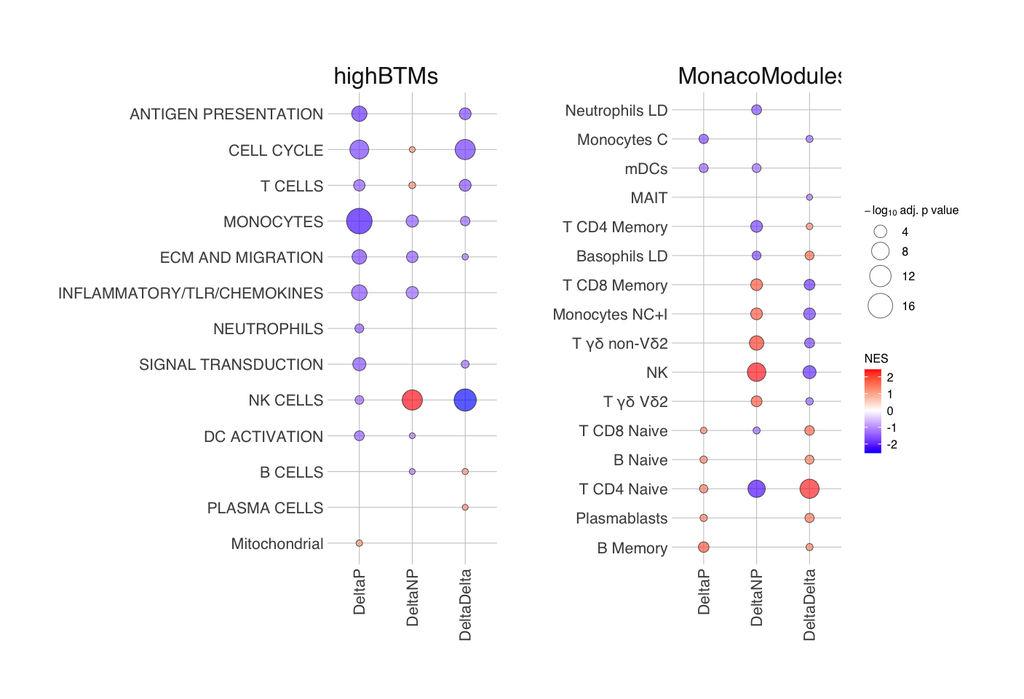